# Practical Machine Learning Project

Romi Kuntsman

July 9, 2016

```r
# rendering options
knitr::opts_chunk$set(echo = TRUE, cache = FALSE)
```

# Introduction

1. How the model was build
2. How cross validation was used
3. What the expected out of sample error is
4. Why different choices were made
5. Use the model to predict 20 different test cases

# Preparations

## Prerequisites

Since we’re dealing with sophisticated machine learning algorithms, whose implementaion may change slightly between versions, we’ll load all the libraries in advance and show the environment information and all libraries used. This will help the reproducibility of the experiment. We will also set a constant random seed, to make sure the all randomized calculations are the same for every execution.

```r
# libraries
library("corrplot")
library("lattice")
library("ggplot2")
library("caret")
library("randomForest")
# set contact random seed
set.seed(1560706)
```

## Loading the Data

```r
read_remote_csv <- function(src_url_prefix, file_name){
  data_dir = "./data/"
  dir.create(data_dir, showWarnings = FALSE)
  dest_file = paste0(data_dir, file_name);
  src_url = paste0(src_url_prefix, file_name);

  if (!file.exists(dest_file)) {
    download.file(url = src_url, destfile = dest_file, method="curl")
  }
  # some columns have empty data with empty string and some with "NA" string
  # we want to treat both of these as N/A so they can be removed when subsetting
  return (read.csv(dest_file, sep = ",", strip.white = TRUE, na.strings = c("", " ", "NA")))
}

data_url_prefix = "https://d396qusza40orc.cloudfront.net/predmachlearn/"

training_data_raw = read_remote_csv(data_url_prefix, "pml-training.csv")
test_data_raw = read_remote_csv(data_url_prefix, "pml-testing.csv")
```

```r
dim(training_data_raw)
```

```
## [1] 19622   160
```

```r
dim(test_data_raw)
```

```
## [1]  20 160
```

## Cleaning the Data

The dataset contains multiple measurements per window, grouped with the “num_window” column, and summarized in one ending row with “new_window”=true. Our goal in this project is to build a predictor of activity based on a single row of measurement. Therefore we’ll first remove the summary rows, and then remove columns which otherwise appear only in the summary rows, and columns with very high cardinality (such as timestamps) or very low cardinality (such as window numbers and user names). We will use the training data to choose the column set, and then take these columns from both the training and test sets.

```r
# remove window summary rows which contain different columns than we want
training_data_nowindowsum = subset(training_data_raw, new_window=="no")

# remove the key columns (username, timestamp, window) which are not predictors
training_data_nokeycols = subset(training_data_nowindowsum, select =
  (grep("^X|user|timestamp|window", names(training_data_nowindowsum), invert = TRUE)))

# remove columns with no data
training_data_full = subset(training_data_nokeycols, select =
  (colSums(is.na(training_data_nokeycols)) == 0))

# use columns the selected columns from training data
test_data_selected_columns = names(training_data_full)

# instead of "classe" column which is only in training data,
# use "problem_id" which is only in test data
test_data_selected_columns[53] <- "problem_id"

# subset test data to have same columns as training (except for last one)
test_data = subset(test_data_raw, select = test_data_selected_columns)
```

## Partitioning the Data

The test data we have is without the class, those are the examples we want to predict. In order to use cross validation, we will now split the training data into training and validation data sets.

```r
# 75% training, 25% validation
training_data_partition = createDataPartition(training_data_full$classe, p = 0.75, list = FALSE)
training_data <- training_data_full[training_data_partition, ]
validation_data <- training_data_full[-training_data_partition, ]
```

```r
dim(training_data)
```

```
## [1] 14414    53
```

```r
dim(validation_data)
```

```
## [1] 4802   53
```

```r
dim(test_data)
```

```
## [1] 20 53
```

```r
names(training_data)
```

```
##  [1] "roll_belt"            "pitch_belt"           "yaw_belt"
##  [4] "total_accel_belt"     "gyros_belt_x"         "gyros_belt_y"
##  [7] "gyros_belt_z"         "accel_belt_x"         "accel_belt_y"
## [10] "accel_belt_z"         "magnet_belt_x"        "magnet_belt_y"
## [13] "magnet_belt_z"        "roll_arm"             "pitch_arm"
## [16] "yaw_arm"              "total_accel_arm"      "gyros_arm_x"
## [19] "gyros_arm_y"          "gyros_arm_z"          "accel_arm_x"
## [22] "accel_arm_y"          "accel_arm_z"          "magnet_arm_x"
## [25] "magnet_arm_y"         "magnet_arm_z"         "roll_dumbbell"
## [28] "pitch_dumbbell"       "yaw_dumbbell"         "total_accel_dumbbell"
## [31] "gyros_dumbbell_x"     "gyros_dumbbell_y"     "gyros_dumbbell_z"
## [34] "accel_dumbbell_x"     "accel_dumbbell_y"     "accel_dumbbell_z"
## [37] "magnet_dumbbell_x"    "magnet_dumbbell_y"    "magnet_dumbbell_z"
## [40] "roll_forearm"         "pitch_forearm"        "yaw_forearm"
## [43] "total_accel_forearm"  "gyros_forearm_x"      "gyros_forearm_y"
## [46] "gyros_forearm_z"      "accel_forearm_x"      "accel_forearm_y"
## [49] "accel_forearm_z"      "magnet_forearm_x"     "magnet_forearm_y"
## [52] "magnet_forearm_z"     "classe"
```

# Exploration

Exploring the data and relationships in it is beyond the scope of this project, but still to get a little sense of how much most of our predictor variables are (not!) correlation, we can take a lok at correlation plot below.

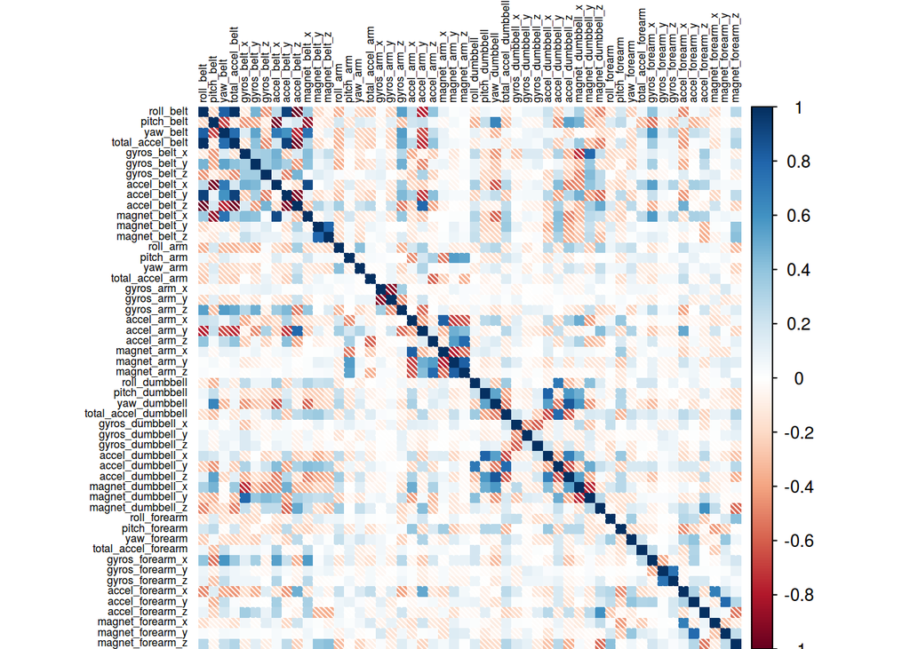

```r
corrPlot <- cor(training_data[ , -length(names(training_data))])
corrplot(corrPlot, method="shade", tl.cex = 0.5, tl.col = "black")
```

# Machine Learning Model

For our model, we’ll use the Random Forest algorithm, which automatically selects features, and overcomes correlations and outliers in the predictor variables.

## Random Forest Model

```r
# it's better to run repeat cross-validation with multiple repeat
# explanation and examples can be found here:
# from here: https://topepo.github.io/caret/training.html
# but it takes a very long time to run, so we'll settle for less here

control <- trainControl(method = "cv", number = 3)

system.time(model <- train(classe ~ ., data = training_data,
                           method = "rf", prox = TRUE, trControl = control,
                           allowParallel = TRUE))
```

```
##     user   system  elapsed
## 1148.202   24.173 1173.416
```

Here’s the random forest results:

```r
print(model)
```

```
## Random Forest
##
## 14414 samples
##    52 predictors
##     5 classes: 'A', 'B', 'C', 'D', 'E'
##
## No pre-processing
## Resampling: Cross-Validated (3 fold)
## Summary of sample sizes: 9609, 9610, 9609
## Resampling results across tuning parameters:
##
##   mtry  Accuracy   Kappa
##    2    0.9910504  0.9886765
##   27    0.9900095  0.9873593
##   52    0.9851531  0.9812130
##
## Accuracy was used to select the optimal model using  the largest value.
## The final value used for the model was mtry = 2.
```

Here’s the final model selected:

```r
print(model$finalModel)
```

```
##
## Call:
##  randomForest(x = x, y = y, mtry = param$mtry, proximity = TRUE,      allowParallel = TRUE)
##                Type of random forest: classification
##                      Number of trees: 500
## No. of variables tried at each split: 2
##
##         OOB estimate of  error rate: 0.62%
## Confusion matrix:
##      A    B    C    D    E  class.error
## A 4101    3    0    0    0 0.0007309942
## B   14 2772    3    0    0 0.0060953747
## C    0   21 2491    2    0 0.0091487669
## D    0    0   33 2325    3 0.0152477764
## E    0    0    4    7 2635 0.0041572184
```

## Confusion Matrix

Now let’s see the confusion matrix on the validation data:

```r
validation_data_predict = predict(model, validation_data)

confusionMatrix(validation_data$classe, validation_data_predict)
```

```
## Confusion Matrix and Statistics
##
##           Reference
## Prediction    A    B    C    D    E
##          A 1365    2    0    0    0
##          B    9  917    3    0    0
##          C    0    1  837    0    0
##          D    0    0   31  754    1
##          E    0    0    0    4  878
##
## Overall Statistics
##
##                Accuracy : 0.9894
##                  95% CI : (0.9861, 0.9921)
##     No Information Rate : 0.2861
##     P-Value [Acc > NIR] : < 2.2e-16
##
##                   Kappa : 0.9866
##  Mcnemar's Test P-Value : NA
##
## Statistics by Class:
##
##                      Class: A Class: B Class: C Class: D Class: E
## Sensitivity            0.9934   0.9967   0.9610   0.9947   0.9989
## Specificity            0.9994   0.9969   0.9997   0.9921   0.9990
## Pos Pred Value         0.9985   0.9871   0.9988   0.9593   0.9955
## Neg Pred Value         0.9974   0.9992   0.9914   0.9990   0.9997
## Prevalence             0.2861   0.1916   0.1814   0.1579   0.1830
## Detection Rate         0.2843   0.1910   0.1743   0.1570   0.1828
## Detection Prevalence   0.2847   0.1935   0.1745   0.1637   0.1837
## Balanced Accuracy      0.9964   0.9968   0.9804   0.9934   0.9989
```

```r
postResample(validation_data_predict, validation_data$classe)
```

```
##  Accuracy     Kappa
## 0.9893794 0.9865625
```

98.9% accuracy - nice!

## Model Predictions

And finally, using the predictor on the test data:

```r
predict(model, test_data)
```

```
##  [1] B A B A A E D B A A B C B A E E A B B B
## Levels: A B C D E
```

# References

- Data at: [“Human Activity Recognition” dataset](http://groupware.les.inf.puc-rio.br/har) from [Groupware@LES](http://groupware.les.inf.puc-rio.br/)
- Code at: [My GitHub repository](https://github.com/rmkn85/Coursera-PracticalMachineLearning/tree/gh-pages)
- Report at: [Project Published in GitHub Pages](https://rmkn85.github.io/Coursera-PracticalMachineLearning/)
- Assignment at: [Coursera Practical Machine Learning Coursa](https://www.coursera.org/learn/practical-machine-learning/)
- Tips on R Markdown at: (R Markdown HTML Document Format)[http://rmarkdown.rstudio.com/html_document_format.html]